# lab08

Yixuan Li, UPI:yil845

3 October 2021

### The Data: The data source for this lab is from UCI Machine Learning Repository,the Vertebral Column data set.

### Import data

```r
library(MASS)
library(class)
library(gam)
library(nnet)
library(e1071)
library(parallel)
vc = read.csv("vertebral-column.csv", stringsAsFactors=TRUE)
head(vc)
```

[output not shown]

```r
table(vc$class)
```

```
##
##  DH  NO  SL
##  60 100 150
```

## Exploration

### 1,These codes create a pairwise scatterplot, with observations of different classes shown in different colors.

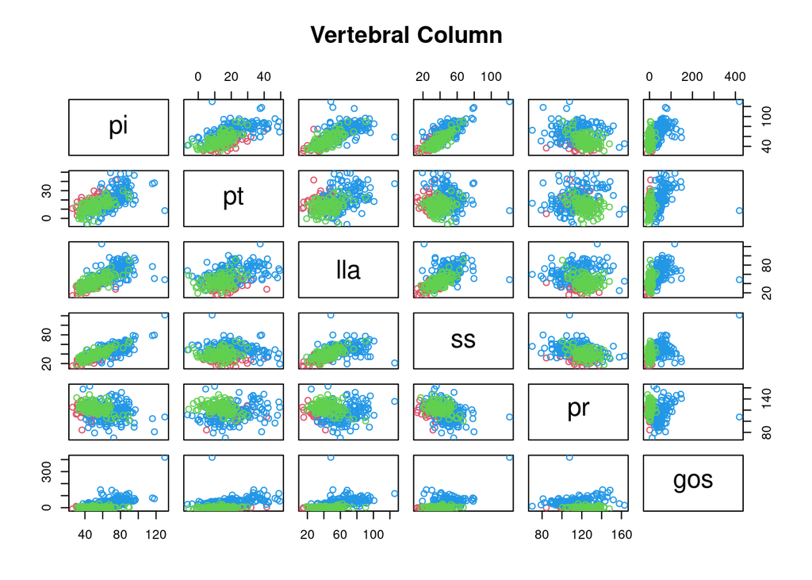

```r
plot(vc[,-7], col=as.numeric(vc[,7])+1, pch=1, main="Vertebral Column" )
```

## Classification

#### Five classification methods are done with underlying codes. Predictions and models are developed based on orginal datasets. The confusion matrix and (resubstitution) classification accuracy are computed as following:

### 2,Linear discriminant analysis.

```r
r.ld = lda(class ~ ., data=vc)
yhat.ld = predict(r.ld, newdata=vc)$class
table(vc$class, yhat.ld)           # confusion table
```

```
##     yhat.ld
##       DH  NO  SL
##   DH  39  20   1
##   NO  12  79   9
##   SL   4  11 135
```

```r
(A.ld = mean(vc$class == yhat.ld))    # Classfication accuracy
```

```
## [1] 0.816129
```

### 3, Quadratic discriminant analysis.

```r
(r.qd = qda(class ~ ., data=vc))
```

```
## Call:
## qda(class ~ ., data = vc)
##
## Prior probabilities of groups:
##        DH        NO        SL
## 0.1935484 0.3225806 0.4838710
##
## Group means:
##          pi       pt      lla       ss       pr       gos
## DH 47.63833 17.39867 35.46350 30.24000 116.4750  2.479333
## NO 51.68560 12.82180 43.54230 38.86380 123.8912  2.187000
## SL 71.51367 20.74800 64.10987 50.76613 114.5183 51.896867
```

```r
(yhat.qd = predict(r.qd, newdata=vc)$class)
```

```
##   [1] DH DH NO DH DH NO NO NO NO SL DH DH DH DH DH NO NO NO NO DH NO DH SL DH DH
##  [26] DH DH DH DH NO DH DH DH NO DH DH NO DH DH DH DH NO DH DH NO DH DH DH DH DH
##  [51] DH DH DH DH DH DH DH DH DH NO SL SL SL SL SL SL SL SL NO SL SL SL SL SL SL
##  [76] SL SL SL SL SL SL SL SL SL SL SL SL SL SL SL SL SL SL SL SL SL SL SL SL SL
## [101] SL SL SL SL SL DH SL SL SL SL SL SL SL SL SL SL SL SL SL SL SL SL SL SL SL
## [126] SL SL SL SL SL SL SL SL SL SL SL SL SL SL SL SL SL SL SL SL SL SL SL SL SL
## [151] SL SL SL SL SL SL SL SL SL SL SL SL SL SL SL SL SL SL SL SL SL SL SL SL SL
## [176] SL SL SL SL SL SL SL SL SL SL SL SL SL SL SL SL SL SL SL SL SL SL SL SL SL
## [201] SL SL SL SL SL SL SL SL SL SL DH NO NO NO NO NO NO NO NO DH DH NO SL SL SL
## [226] NO NO NO NO NO NO NO NO NO NO NO NO NO NO NO NO NO NO NO DH NO DH DH NO DH
## [251] NO NO NO NO NO SL NO NO NO NO NO NO NO NO NO NO NO NO NO DH NO DH DH NO NO
## [276] NO NO NO NO NO NO NO NO NO NO NO NO NO NO NO DH DH NO NO NO NO NO DH NO NO
## [301] NO NO DH NO NO NO DH NO NO NO
## Levels: DH NO SL
```

```r
table(vc$class, yhat.qd)     # confusion table
```

```
##     yhat.qd
##       DH  NO  SL
##   DH  42  16   2
##   NO  15  81   4
##   SL   1   1 148
```

```r
(A.qd = mean(vc$class == yhat.qd))    # Classfication accuracy
```

```
## [1] 0.8741935
```

### 4,Naive Bayes.

```r
(r.nb = naiveBayes(class ~ ., data=vc))
```

```
##
## Naive Bayes Classifier for Discrete Predictors
##
## Call:
## naiveBayes.default(x = X, y = Y, laplace = laplace)
##
## A-priori probabilities:
## Y
##        DH        NO        SL
## 0.1935484 0.3225806 0.4838710
##
## Conditional probabilities:
##     pi
## Y        [,1]     [,2]
##   DH 47.63833 10.69694
##   NO 51.68560 12.36790
##   SL 71.51367 15.10908
##
##     pt
## Y        [,1]      [,2]
##   DH 17.39867  7.016809
##   NO 12.82180  6.778658
##   SL 20.74800 11.505857
##
##     lla
## Y        [,1]      [,2]
##   DH 35.46350  9.767804
##   NO 43.54230 12.361581
##   SL 64.10987 16.396336
##
##     ss
## Y        [,1]      [,2]
##   DH 30.24000  7.555102
##   NO 38.86380  9.623776
##   SL 50.76613 12.318389
##
##     pr
## Y        [,1]      [,2]
##   DH 116.4750  9.355709
##   NO 123.8912  9.013755
##   SL 114.5183 15.580436
##
##     gos
## Y         [,1]      [,2]
##   DH  2.479333  5.531449
##   NO  2.187000  6.307020
##   SL 51.896867 40.107622
```

```r
(yhat.nb = predict(r.nb, newdata=vc))   # predicted classes
```

```
##   [1] DH DH NO SL DH DH NO NO NO DH DH DH DH DH DH DH NO NO DH DH NO NO SL DH DH
##  [26] DH DH DH DH NO DH DH DH DH DH DH NO DH DH DH DH DH DH NO NO DH DH DH DH DH
##  [51] DH SL DH DH DH DH DH DH DH DH SL SL SL SL SL SL SL SL NO SL SL SL SL SL SL
##  [76] SL SL SL SL NO SL SL SL SL SL SL SL SL SL SL SL SL SL SL SL SL SL SL SL SL
## [101] SL SL SL SL SL NO SL SL SL SL SL SL SL SL SL NO SL SL NO SL SL SL SL SL SL
## [126] SL SL SL SL SL SL SL SL SL SL SL SL SL SL SL SL SL SL SL SL SL SL SL SL SL
## [151] SL SL SL SL SL SL SL SL SL SL SL SL SL SL SL SL SL SL SL SL SL SL SL SL SL
## [176] SL SL SL SL SL SL SL SL SL SL SL SL SL SL SL SL SL SL SL SL SL SL SL SL SL
## [201] SL SL SL SL SL SL SL SL SL SL DH NO NO NO NO NO NO NO NO DH DH NO SL SL SL
## [226] NO NO NO DH NO NO NO NO NO NO NO NO NO NO NO DH NO NO NO NO NO DH DH NO DH
## [251] NO NO NO SL SL SL NO NO NO NO NO SL DH NO NO NO NO NO NO DH NO DH DH NO DH
## [276] NO NO NO NO NO DH NO NO NO NO NO NO NO SL NO DH DH NO NO NO NO DH DH NO SL
## [301] NO SL DH NO NO DH DH NO NO NO
## Levels: DH NO SL
```

```r
table(vc$class, yhat.nb)     # confusion table
```

```
##     yhat.nb
##       DH  NO  SL
##   DH  45  12   3
##   NO  21  69  10
##   SL   0   5 145
```

```r
(A.nb = mean(vc$class == yhat.nb))    # Classfication accuracy
```

```
## [1] 0.8354839
```

```r
## result is hidden due to long list
(yhat.nb = predict(r.nb, newdata=vc, type="raw"))   # posterior probabilities
```

### 5, Multinomial logistic regression.

```r
(r.mlr = multinom(class ~ ., data=vc))
```

```
## Call:
## multinom(formula = class ~ ., data = vc)
##
## Coefficients:
##    (Intercept)        pi         pt        lla         ss         pr
## NO   -20.23244 -4.584673   4.485069 0.03527065   4.737024 0.13049227
## SL   -21.71458 16.597946 -16.609482 0.02184513 -16.390098 0.07798643
##             gos
## NO -0.005418782
## SL  0.309521250
##
## Residual Deviance: 179.0885
## AIC: 207.0885
```

```r
table(vc$class, predict(r.mlr, vc))    # Confusion table
```

```
##
##       DH  NO  SL
##   DH  40  19   1
##   NO  13  85   2
##   SL   1   3 146
```

```r
A.mlr<- mean(vc$class == predict(r.mlr, vc))   # classification accuracy
A.mlr
```

```
## [1] 0.8741935
```

### 6, K-nearest neighbours (with K=10).

```r
yhat.knn = knn(train=vc[,1:6], test=vc[,1:6], cl=vc[,7], k=10)   # K = 10
t<-table(vc[,7], yhat.knn)
t  # Confusion table
```

```
##     yhat.knn
##       DH  NO  SL
##   DH  43  16   1
##   NO  12  86   2
##   SL   1   3 146
```

```r
A.knn<-sum(diag(t))/sum(t) # classification accuracy
A.knn
```

```
## [1] 0.8870968
```

## Primary Performance Evaluation

### 7,Present the resulting classification accuracy for all five classification methods in a table.

### From this table, what can we say about the relative performance of these methods for the data set? The result shows that “Quadratic discriminant analysis” “Multinomial logistic regression” and “K-nearest neighbours” have the better classification accuracy. KNN gives highest accuracy.

```r
m <- matrix(0,5,2)
colnames(m)<-c("Method","Classification accuracy")
m[,1] = c("Linear discriminant analysis","Quadratic discriminant analysis","Naive Bayes","Multinomial logistic regression","K-nearest neighbours")
m[,2] = c(A.ld,A.qd,A.nb,A.mlr,A.knn)
m
```

```
##      Method                            Classification accuracy
## [1,] "Linear discriminant analysis"    "0.816129032258065"
## [2,] "Quadratic discriminant analysis" "0.874193548387097"
## [3,] "Naive Bayes"                     "0.835483870967742"
## [4,] "Multinomial logistic regression" "0.874193548387097"
## [5,] "K-nearest neighbours"            "0.887096774193548"
```

## Multiple Logistic Regression and Generalised Additive Models

### 8,Create a response variable from variable class so that both classes DH and SL are relabelled as AB (Abnormal).

### Use glm() to build a multiple logistic regression model for this new class variable, and compute the confusion matrix and resubstitution classification accuracy.

```r
# create a new column called newclass
vc$newclass <- vc$class
# change levels of "DH" and "SL" in column newclass into "AB"
levels(vc$newclass)[levels(vc$newclass)=="DH" | levels(vc$newclass)=="SL" ] <- "AB"

# glm.fit: algorithm did not converge glm.fit: fitted probabilities numerically 0 or 1 occurred
(r.glm = glm(newclass ~ pi+pt+lla+ss+pr+gos, data=vc, family=binomial))
```

```
##
## Call:  glm(formula = newclass ~ pi + pt + lla + ss + pr + gos, family = binomial,
##     data = vc)
##
## Coefficients:
## (Intercept)           pi           pt          lla           ss           pr
##   -15.14270     12.88787    -12.96465      0.01939    -12.79191      0.10684
##         gos
##    -0.16794
##
## Degrees of Freedom: 309 Total (i.e. Null);  303 Residual
## Null Deviance:       389.9
## Residual Deviance: 178.1     AIC: 192.1
```

```r
yhat = as.numeric(predict(r.glm, vc, type="response") > 0.5)+1        # Predicted classes
table(vc$newclass, levels(vc$newclass)[yhat])                         # Confusion table
```

```
##
##       AB  NO
##   AB 188  22
##   NO  22  78
```

```r
mean((vc$newclass) == levels(vc$newclass)[yhat])                      # classification accuracy
```

```
## [1] 0.8580645
```

### 9,Use step() to find the AIC-selected model, with backward selection.

### Which variables are removed by the AIC? The variables lla & ss are removed by AIC backward selection. The variables “pi”, “pt”, “pr” and “gos” show very significiant P values with "***".

```r
rstep = step(r.glm, type="backward")    # backward selection. Only AIC
```

```
## Start:  AIC=192.13
## newclass ~ pi + pt + lla + ss + pr + gos
```

```
##        Df Deviance    AIC
## - ss    1   178.27 190.27
## - pi    1   178.27 190.27
## - pt    1   178.27 190.27
## - lla   1   178.86 190.86
## <none>      178.13 192.13
## - pr    1   209.31 221.31
## - gos   1   302.31 314.31
```

```
##
## Step:  AIC=190.27
## newclass ~ pi + pt + lla + pr + gos
```

```
##        Df Deviance    AIC
## - lla   1   178.95 188.95
## <none>      178.27 190.27
## - pi    1   189.08 199.08
## - pt    1   202.23 212.23
## - pr    1   209.36 219.36
## - gos   1   303.45 313.45
```

```
##
## Step:  AIC=188.95
## newclass ~ pi + pt + pr + gos
```

```
##        Df Deviance    AIC
## <none>      178.95 188.95
## - pt    1   208.55 216.55
## - pr    1   212.18 220.18
## - pi    1   212.53 220.53
## - gos   1   310.54 318.53
```

```r
summary(rstep)
```

```
##
## Call:
## glm(formula = newclass ~ pi + pt + pr + gos, family = binomial,
##     data = vc)
##
## Deviance Residuals:
##      Min        1Q    Median        3Q       Max
## -2.21933  -0.37927  -0.03193   0.40184   2.79266
##
## Coefficients:
##              Estimate Std. Error z value Pr(>|z|)
## (Intercept) -15.45723    3.27273  -4.723 2.32e-06 ***
## pi            0.11495    0.02266   5.072 3.94e-07 ***
## pt           -0.18140    0.03784  -4.794 1.63e-06 ***
## pr            0.10895    0.02279   4.780 1.75e-06 ***
## gos          -0.16538    0.02288  -7.227 4.92e-13 ***
## ---
## Signif. codes:  0 '***' 0.001 '**' 0.01 '*' 0.05 '.' 0.1 ' ' 1
##
## (Dispersion parameter for binomial family taken to be 1)
##
##     Null deviance: 389.86  on 309  degrees of freedom
## Residual deviance: 178.95  on 305  degrees of freedom
## AIC: 188.95
##
## Number of Fisher Scoring iterations: 8
```

### 10,Extend the AIC-selected model with gam() so that each linear term is replaced with a smoothing spline of 5 degrees of freedom. Take a visual approach to reasonably lower the degrees of freedom in each term.

### Visually speaking 2-3 degrees of freedom are the best, smoothly fitted. the computed confusion matrix and classification accuracy are based on 2 degrees of freedom.

```r
(r1 = gam(newclass ~ s(pi, 1) + s(pt, 1) + s(pr, 1) + s(gos,1), data=vc, family=binomial()))
```

```
## Call:
## gam(formula = newclass ~ s(pi, 1) + s(pt, 1) + s(pr, 1) + s(gos,
##     1), family = binomial(), data = vc)
##
## Degrees of Freedom: 309 total; 304.9999 Residual
## Residual Deviance: 178.9455
```

```r
(r2 = gam(newclass ~ s(pi, 2) + s(pt, 2) + s(pr, 2) + s(gos,2), data=vc, family=binomial()))
```

```
## Call:
## gam(formula = newclass ~ s(pi, 2) + s(pt, 2) + s(pr, 2) + s(gos,
##     2), family = binomial(), data = vc)
##
## Degrees of Freedom: 309 total; 300.9999 Residual
## Residual Deviance: 163.5696
```

```r
(r3 = gam(newclass ~ s(pi, 3) + s(pt, 3) + s(pr, 3) + s(gos,3), data=vc, family=binomial()))
```

```
## Call:
## gam(formula = newclass ~ s(pi, 3) + s(pt, 3) + s(pr, 3) + s(gos,
##     3), family = binomial(), data = vc)
##
## Degrees of Freedom: 309 total; 297.0002 Residual
## Residual Deviance: 158.5306
```

```r
(r4 = gam(newclass ~ s(pi, 4) + s(pt, 4) + s(pr, 4) + s(gos,4), data=vc, family=binomial()))
```

```
## Call:
## gam(formula = newclass ~ s(pi, 4) + s(pt, 4) + s(pr, 4) + s(gos,
##     4), family = binomial(), data = vc)
##
## Degrees of Freedom: 309 total; 293.0001 Residual
## Residual Deviance: 154.4163
```

```r
(r5 = gam(newclass ~ s(pi, 5) + s(pt, 5) + s(pr, 5) + s(gos,5), data=vc, family=binomial()))
```

```
## Call:
## gam(formula = newclass ~ s(pi, 5) + s(pt, 5) + s(pr, 5) + s(gos,
##     5), family = binomial(), data = vc)
##
## Degrees of Freedom: 309 total; 288.9995 Residual
## Residual Deviance: 149.6359
```

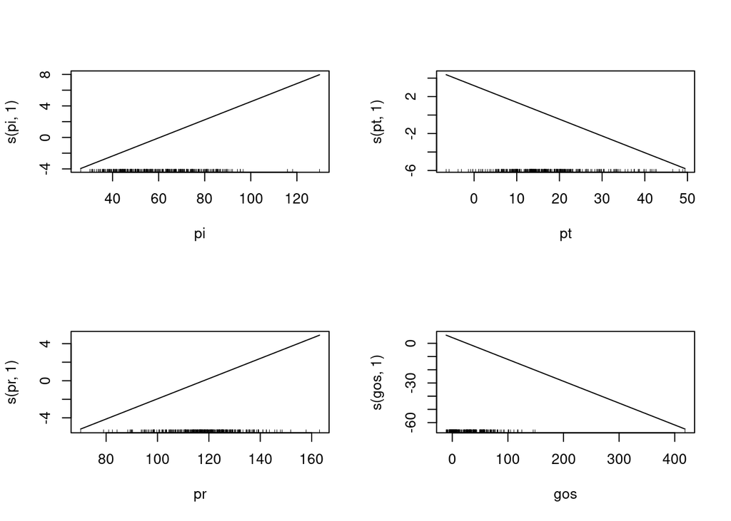

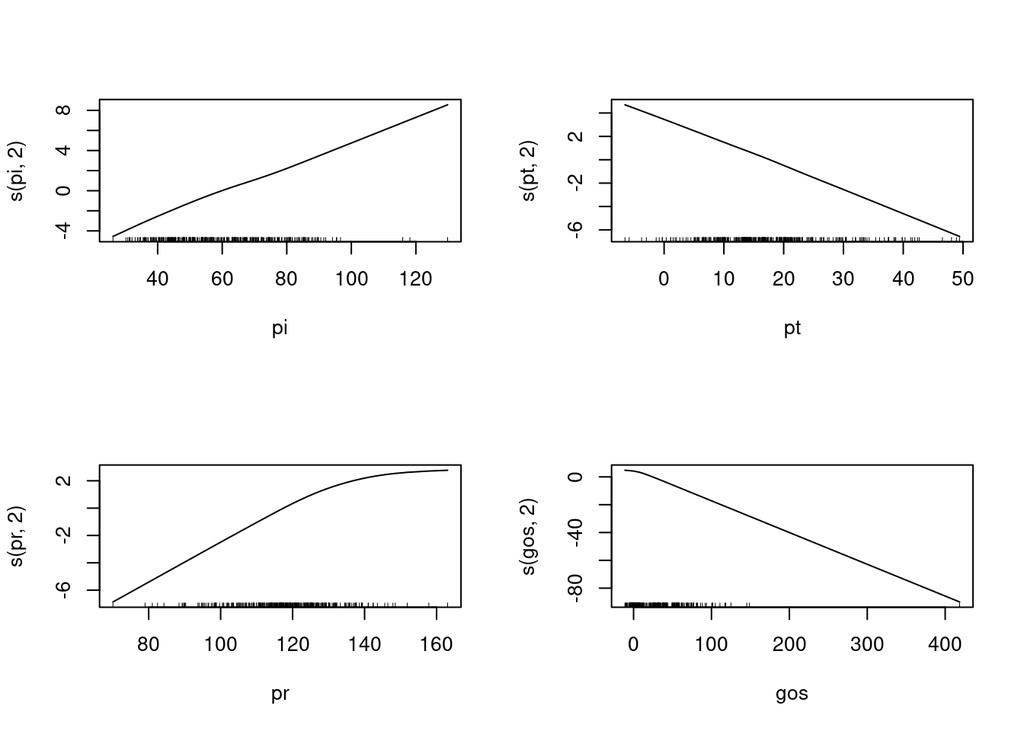

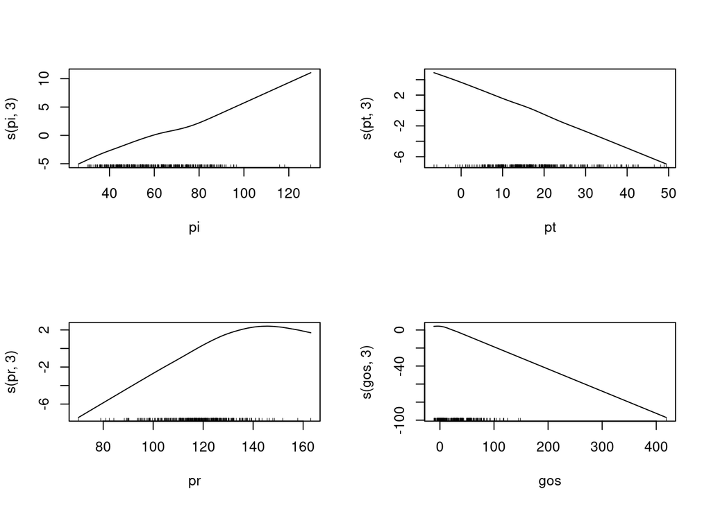

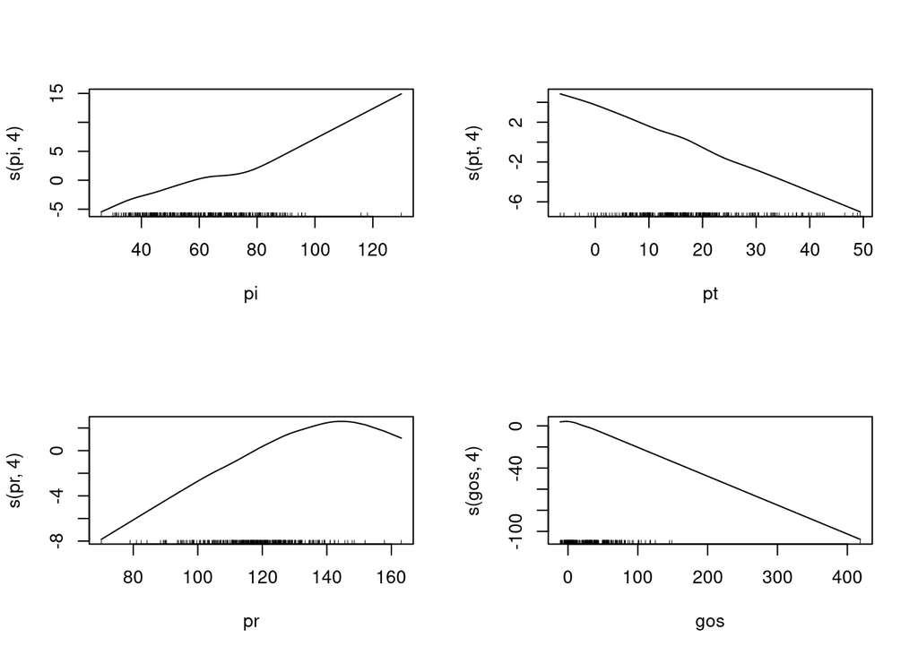

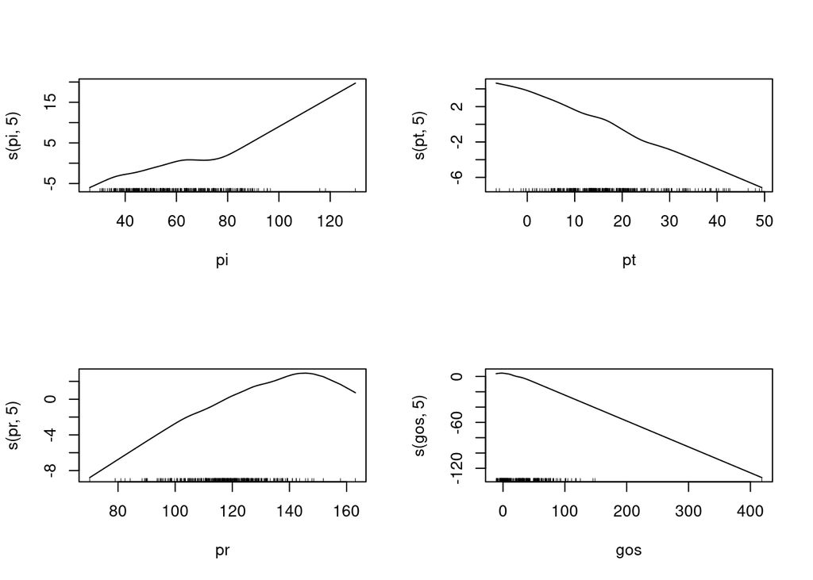

```r
par(mfrow=c(2,2))
plot(r1);plot(r2);plot(r3);plot(r4);plot(r5)
```

```r
## the 2 degree freedom shows better fitting
p2 = predict(r2, vc)   # Pr(Y = 1)
table(vc$newclass, as.numeric(p2 > 0.5) + 1)  # confusion table
```

```
##
##        1   2
##   AB 197  13
##   NO  24  76
```

```r
# 2 degree classification accuracy
sum(diag(table(vc$newclass, as.numeric(p2 > 0.5) + 1)))/sum(table(vc$newclass, as.numeric(p2 > 0.5) + 1))
```

```
## [1] 0.8806452
```

## Cross-validation and Parallel Computing

### 11, Use 10 repetitions of 10-fold cross-validation to evaluate the performance of the 5 classification methods.

### The resulting classification accuracy of all five classification methods are shown in a table. The result shows the Multinomial Logistic Regression has highest classification accuracy for this dataset.

```r
R = 10                   # number of repetitions
m = 5                    # Five classification methods we want to use
n = nrow(vc)             # data size
K = 10                   # K-fold CV

## function for shuffle the i-th sample from n size of data by K fold selection.
test.set = function(i, n, K=10) {
  if(i < 1 || i > K)
    stop(" i out of range (1, K)")
  start = round(1 + (i-1) * n / K)
  end = ifelse(i == K, n, round(i * n / K))
  start:end
}

set.seed(389)           # set a random seed
Atable = matrix(nrow=R*K, ncol=m)
colnames(Atable) = c("Linear","Quadratic","NaiveBayes","Multinomial","KNN")
for(i in 1:R) {                  # for each repetition
  ind = sample(n)                # shuffle index

    for(k in 1:K) {                # for each fold
    index = ind[test.set(k, n, K)]
    test = vc[index,]
    train = vc[-index,]
    # Classification methods
      ## Linear discriminant analysis
      (r1 = lda(class ~ pi+pt+lla+ss+pr+gos, data=train))
      A1 = sum(diag(table(test$class, predict(r1, newdata=test)$class))/sum(table(test$class, predict(r1, newdata=test)$class)))
      ## Quardratic discriminant analysis
      (r2 = qda(class ~ pi+pt+lla+ss+pr+gos, data=train))
      A2 = sum(diag(table(test$class, predict(r2, newdata=test)$class))/ sum(table(test$class, predict(r2, newdata=test)$class)))
      ## Naive Bayes
      (r3 = naiveBayes(class ~pi+pt+lla+ss+pr+gos, data=train))
      A3 = sum(diag(table(test$class, predict(r3, newdata=test)))/ sum(table(test$class, predict(r3, newdata=test))))
      ## Multinomial Logistic Regression
      (r4 = multinom(class ~pi+pt+lla+ss+pr+gos, data=train))
      A4 = sum(diag(table(test$class, predict(r4, test)))/  sum(table(test$class, predict(r4, test))))
      ##KNN K = 10
      A5 = sum(diag(table(test[,7], knn(train=train[,1:6], test=test[,1:6], cl=train[,7], k=10)))/ sum(table(test[,7], knn(train=train[,1:6], test=test[,1:6], cl=train[,7], k=10))))
      ## Classification accuracy
      Atable[K*(i-1)+k,] = c(A1,A2,A3,A4,A5)

  }
}
```

```r
Atable
```

```
##           Linear Quadratic NaiveBayes Multinomial       KNN
##   [1,] 0.8709677 0.8709677  0.7096774   0.9354839 0.8387097
##   [2,] 0.9032258 0.8387097  0.8709677   0.9354839 0.8387097
##   [3,] 0.8709677 0.9354839  0.9032258   0.8709677 0.9354839
##   [4,] 0.7419355 0.8064516  0.7419355   0.8064516 0.7419355
##   [5,] 0.7419355 0.8709677  0.8387097   0.9032258 0.9354839
##   [6,] 0.8064516 0.7741935  0.8064516   0.8064516 0.8064516
##   [7,] 0.8387097 0.7741935  0.7741935   0.8709677 0.8064516
##   [8,] 0.8387097 0.7741935  0.8387097   0.8387097 0.8064516
##   [9,] 0.7741935 0.7741935  0.8387097   0.8064516 0.7741935
##  [10,] 0.7419355 0.8709677  0.9032258   0.8064516 0.7741935
##  [11,] 0.8064516 0.8064516  0.8709677   0.8387097 0.8064516
##  [12,] 0.7741935 0.8064516  0.7096774   0.8709677 0.8064516
##  [13,] 0.9354839 0.8709677  0.9032258   0.9354839 0.9354839
##  [14,] 0.7741935 0.8064516  0.7096774   0.8064516 0.7741935
```

[output cut: 86 more lines]

```r
colMeans(Atable)
```

```
##      Linear   Quadratic  NaiveBayes Multinomial         KNN
##   0.8058065   0.8390323   0.8235484   0.8564516   0.8348387
```

```r
## the result shows the Multinomial Logistic Regression has highest classification accuracy for this dataset.
```

### Additional attempt to search for the optimum k value in KNN. It shows better results when K>=5, among which 7 neighboors KNN gives best prediction accuracy.

```r
R = 10                   # number of repetitions
m = 10                   # K values we want to search (1:10)
n = nrow(vc)             # data size
K = 10                   # K-fold CV

## function for shuffle the i-th sample from n size of data by K fold selection.
test.set = function(i, n, K=10) {
  if(i < 1 || i > K)
    stop(" i out of range (1, K)")
  start = round(1 + (i-1) * n / K)
  end = ifelse(i == K, n, round(i * n / K))
  start:end
}

set.seed(389)           # set a random seed
Atable = matrix(nrow=R*K, ncol=m)

for(i in 1:R) {                  # for each repetition
  ind = sample(n)                # shuffle index
  for(k in 1:K) {                # for each fold
    index = ind[test.set(k, n, K)]
    test = vc[index,]
    train = vc[-index,]
     # for each classification accuracy
    for(j in 1:m) {
      ##KNN K = 10
      Aknn1 = sum(diag(table(test[,7], knn(train=train[,1:6], test=test[,1:6], cl=train[,7], k=j)))/ sum(table(test[,7], knn(train=train[,1:6], test=test[,1:6], cl=train[,7], k=j))))
      ## Classification accuracy
      Atable[K*(i-1)+k,j] = Aknn1
    }
  }
}

colMeans(Atable)
```

```
##  [1] 0.8316129 0.7983871 0.8135484 0.8167742 0.8358065 0.8329032 0.8393548
##  [8] 0.8354839 0.8354839 0.8322581
```

```r
which.max(colMeans(Atable)) ## the 7 neigbours KNN methods has highest classification accuracy.
```

```
## [1] 7
```

### 12, Modify code so that parallel computing can be used, in which each job running in parallel is only for the computation about one fold out of 10 (i.e., one training set and one test set). Make sure that the same subsamples are used by different methods and that the results are reproducible.Compare timings with 1, 5, 10, 20 cores.

```r
## function for shuffle the i-th sample from n size of data by K fold selection.
 test.set = function(i, n, K) {
    if(i < 1 || i > K)
    stop(" i out of range (1, K)")
    start = round(1 + (i-1) * n / K)
    end = ifelse(i == K, n, round(i * n / K))
    start:end
 }

## function AClass for 5 different classification methods, A1:A5 are Classification accuracy
Aclass<-function(i) {
        set.seed(389+i%%K)
        ## shuffle data index when i%%10 =1
        if (i%%K == 1) {
        ind = sample(n)
        }
        ## generate test / train datasets
        index = ind[test.set(i%%K+1, n, K)]
        test  = vc[index,]
        head(test)
        train = vc[-index,]
# Classification methods: classification accuracy 'A' is sum of diagonal of confusion table / sum of all.
      ## Linear discriminant analysis
      (r1 = lda(class ~ pi+pt+lla+ss+pr+gos, data=train))
      A1 = sum(diag(table(test$class, predict(r1, newdata=test)$class))/sum(table(test$class, predict(r1, newdata=test)$class)))
      ## Quardratic discriminant analysis
      (r2 = qda(class ~ pi+pt+lla+ss+pr+gos, data=train))
      A2 = sum(diag(table(test$class, predict(r2, newdata=test)$class))/ sum(table(test$class, predict(r2, newdata=test)$class)))
      ## Naive Bayes
      (r3 = naiveBayes(class ~pi+pt+lla+ss+pr+gos, data=train))
      A3 = sum(diag(table(test$class, predict(r3, newdata=test)))/ sum(table(test$class, predict(r3, newdata=test))))
      ## Multinomial Logistic Regression
      (r4 = multinom(class ~pi+pt+lla+ss+pr+gos, data=train))
      A4 = sum(diag(table(test$class, predict(r4, test)))/  sum(table(test$class, predict(r4, test))))
      ##KNN K = 10
      A5 = sum(diag(table(test[,7], knn(train=train[,1:6], test=test[,1:6], cl=train[,7], k=10)))/ sum(table(test[,7], knn(train=train[,1:6], test=test[,1:6], cl=train[,7], k=10))))
      ## Classification accuracy
       c(A1,A2,A3,A4,A5)

}
```

```r
## one Core computing time

system.time({
       R = 10                           # number of repetitions
       n = nrow(vc)                     # data size
       K = 10                           # K-fold CV
       Atable1<- mclapply(1:(R*K), function(x) Aclass(x), mc.set.seed=TRUE, mc.cores=1)
})
```

```
##    user  system elapsed
##   3.809   0.000   3.810
```

```r
## 5 Cores computing time
system.time({
       R = 10                           # number of repetitions
       n = nrow(vc)                     # data size
       K = 10                           # K-fold CV
       Atable5<- mclapply(1:(R*K), function(x) Aclass(x), mc.set.seed=TRUE, mc.cores=5)
})
```

```
##    user  system elapsed
##   4.601   0.193   1.245
```

```r
## 10 Cores computing time
system.time({
       R = 10                           # number of repetitions
       n = nrow(vc)                     # data size
       K = 10                           # K-fold CV
       Atable10<- mclapply(1:(R*K), function(x) Aclass(x), mc.set.seed=TRUE, mc.cores=10)
})
```

```
##    user  system elapsed
##   4.499   0.472   0.679
```

```r
## 20 Cores computing time
system.time({
       R = 10                           # number of repetitions
       n = nrow(vc)                     # data size
       K = 10                           # K-fold CV
       Atable20<- mclapply(1:(R*K), function(x) Aclass(x), mc.set.seed=TRUE, mc.cores=20)
})
```

```
##    user  system elapsed
##   5.277   0.983   0.509
```

```r
## example of 5 cores results
t(matrix(unlist(Atable5),5,100))
```

```
##             [,1]      [,2]      [,3]      [,4]      [,5]
##   [1,] 0.7419355 0.7741935 0.7096774 0.7741935 0.8709677
##   [2,] 0.7419355 0.8709677 0.7741935 0.8387097 0.8064516
##   [3,] 0.7419355 0.8387097 0.8387097 0.8387097 0.8064516
##   [4,] 0.7096774 0.6774194 0.8064516 0.8064516 0.7741935
##   [5,] 0.7419355 0.7741935 0.7741935 0.7741935 0.8387097
##   [6,] 0.7741935 0.8064516 0.8064516 0.7741935 0.8387097
##   [7,] 0.9677419 0.8709677 0.8387097 0.9354839 0.8387097
##   [8,] 0.8387097 0.9354839 0.9354839 0.9354839 0.8709677
##   [9,] 0.8387097 0.9032258 0.7741935 0.8709677 0.8387097
##  [10,] 0.9032258 0.9032258 0.7419355 0.9032258 0.8709677
##  [11,] 0.7419355 0.7741935 0.7096774 0.7741935 0.8709677
##  [12,] 0.7419355 0.8709677 0.7741935 0.8387097 0.8064516
##  [13,] 0.7419355 0.8387097 0.8387097 0.8387097 0.8064516
##  [14,] 0.7096774 0.6774194 0.8064516 0.8064516 0.7741935
```

[output cut: 86 more lines]

```r
### results comparison of parallel computing with multi-cores
core<-rbind(colMeans(t(matrix(unlist(Atable1),5,100))),colMeans(t(matrix(unlist(Atable5),5,100))),colMeans(t(matrix(unlist(Atable10),5,100))),colMeans(t(matrix(unlist(Atable20),5,100))))
dimnames(core)<- list(c("1 core","5cores","10cores","20cores"),c("Linear","Quadratic","NaiveBayes","Multinomial","KNN"))
core
```

```
##         Linear Quadratic NaiveBayes Multinomial       KNN
## 1 core     0.8 0.8354839        0.8   0.8451613 0.8354839
## 5cores     0.8 0.8354839        0.8   0.8451613 0.8354839
## 10cores    0.8 0.8354839        0.8   0.8451613 0.8354839
## 20cores    0.8 0.8354839        0.8   0.8451613 0.8354839
```

```r
colMeans(core)
```

```
##      Linear   Quadratic  NaiveBayes Multinomial         KNN
##   0.8000000   0.8354839   0.8000000   0.8451613   0.8354839
```

## Summary

### In this lab we have learn all different kinds of classification methods, Linear discriminant analysis,Quadratic discriminant analysis,Naive Bayes,Multinomial logistic regression,K-nearest neighbours. All confusion matrix and characterization accuracy are generated. For this dataset the primary evaluation shows that “Quadratic discriminant analysis”, “multinomial logistic regression”, “K-nearest neighbours” have the better results. Cross-validation results show “multinomial logistic regression” gives the highest accuracy that is similar to AIC backward selected model results. Further we explore the parallel coding in VM with 1,5,10,20 cores, the result shows the more cores the less time it takes for computation.